# HDS5301: Regression Methods – HW 7 Answer Key

Published

March 2, 2026

1. **Box-Cox Transformation.** Load the `trees` dataset available in base R. Convert it to a data frame: `trees <- data.frame(trees)`. This dataset provides measurements of the girth, height, and volume of timber in 31 felled black cherry trees. We want to predict `Volume` using `Girth` and `Height`.
   1. Fit a linear model `Volume ~ Girth + Height`. Plot the “Residuals vs Fitted” plot. Do you observe any patterns?
   2. Use the `boxcox` function from the `MASS` package to find the optimal $\lambda$ for transforming the **response** variable `Volume`.
   3. Based on the Box-Cox plot, what is a “convenient” value for $\lambda$? (Hint: Consider the physical formula for the volume of a cylinder or cone, $V \propto r^2 h$).
   4. Fit a new model using the transformed response. Compare the “Residuals vs Fitted” plot of this new model to the original one. Did the transformation improve the diagnostics?
   5. **Be Creative.** Can you propose other transformations, potentially including transforming the predictors, that might result in a better model or one that makes more physical sense? Fit your proposed model and check the diagnostics. (Hint: Think about the physical dimensions involved. Volume is length cubed, while Girth and Height are linear dimensions).

   **Answer:**
   1. **Initial Model:**

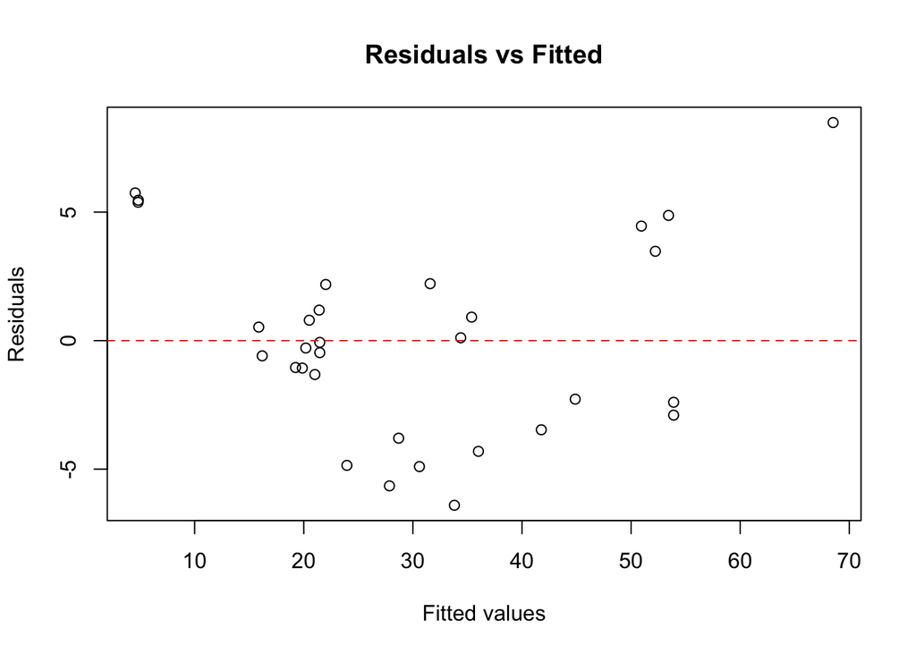

      ```r
      trees <- data.frame(trees)
      model_trees <- lm(Volume ~ Girth + Height, data = trees)

      # Computing residuals and fitted values explicitly
      fitted_vals <- fitted(model_trees)
      resids <- resid(model_trees)

      plot(fitted_vals, resids,
           xlab = "Fitted values",
           ylab = "Residuals",
           main = "Residuals vs Fitted")
      abline(h = 0, lty = 2, col = "red")
      ```

      *Observation:* The Residuals vs Fitted plot clearly shows a curved pattern (U-shape), indicating non-linearity. The variance also seems to increase with fitted values (fanning out).
   2. **Box-Cox:**

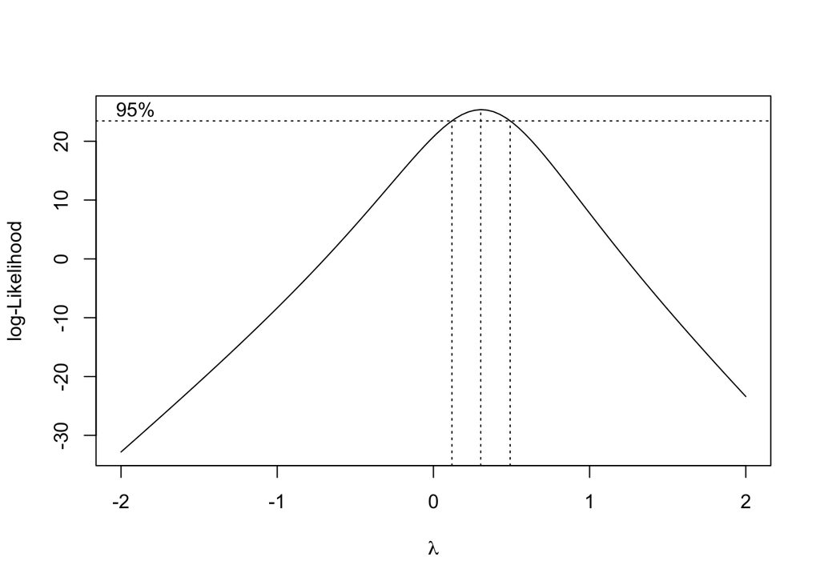

      ```r
      library(MASS)
      bc <- boxcox(model_trees)
      ```

      ```r
      lambda_opt <- bc$x[which.max(bc$y)]
      print(paste("Optimal Lambda:", round(lambda_opt, 3)))
      ```

      ```
      [1] "Optimal Lambda: 0.303"
      ```

      The optimal lambda is essentially close to 1/3.
   3. **Convenient Lambda:** The confidence interval includes $\lambda = 1/3$. *Physical Reasoning:* Volume $V$ has dimensions of Length$^3$. Girth and Height are Length$^1$. Ideally, $V^{1/3} \propto \text{Length}$. So transforming Volume to the cube root ($Volume^{1/3}$) makes dimensional sense to relate linearly to Girth and Height.
   4. **Transformed Model (Response only):**

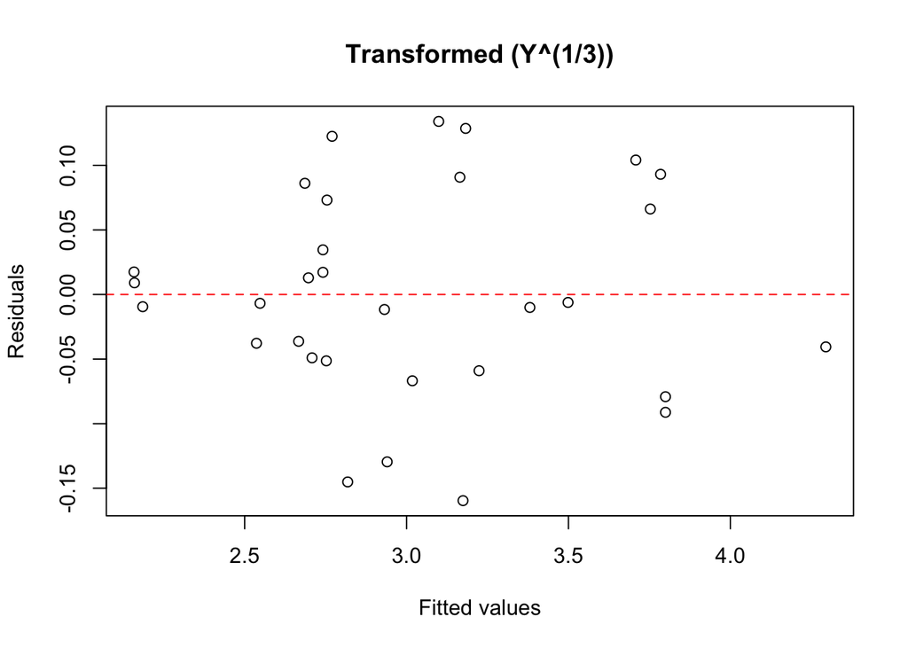

      ```r
      model_trees_trans <- lm(Volume^(1/3) ~ Girth + Height, data = trees)

      # Computing residuals and fitted values explicitly
      fitted_vals_trans <- fitted(model_trees_trans)
      resids_trans <- resid(model_trees_trans)

      plot(fitted_vals_trans, resids_trans,
           xlab = "Fitted values",
           ylab = "Residuals",
           main = "Transformed (Y^(1/3))")
      abline(h = 0, lty = 2, col = "red")
      ```

      The residuals for the transformed model `Volume^(1/3)` look much better (flatter, more random) than the original model.
   5. **Creative Model:** Since trees are essentially cylinders, $V \approx \pi r^2 h$. Taking logs: $\ln(V) \approx \ln(\pi) + 2\ln(r) + \ln(h)$. Girth is circumference ($\approx 2\pi r$), so $\ln(V) \approx \text{const} + 2\ln(\text{Girth}) + \ln(\text{Height})$.

      Let’s fit: `log(Volume) ~ log(Girth) + log(Height)`

      ```r
      model_creative <- lm(log(Volume) ~ log(Girth) + log(Height), data = trees)
      summary(model_creative)
      ```

      ```
      Call:
      lm(formula = log(Volume) ~ log(Girth) + log(Height), data = trees)

      Residuals:
            Min        1Q    Median        3Q       Max
      -0.168561 -0.048488  0.002431  0.063637  0.129223

      Coefficients:
                  Estimate Std. Error t value Pr(>|t|)
      (Intercept) -6.63162    0.79979  -8.292 5.06e-09 ***
      log(Girth)   1.98265    0.07501  26.432  < 2e-16 ***
      log(Height)  1.11712    0.20444   5.464 7.81e-06 ***
      ---
      Signif. codes:  0 '***' 0.001 '**' 0.01 '*' 0.05 '.' 0.1 ' ' 1

      Residual standard error: 0.08139 on 28 degrees of freedom
      Multiple R-squared:  0.9777,    Adjusted R-squared:  0.9761
      F-statistic: 613.2 on 2 and 28 DF,  p-value: < 2.2e-16
      ```

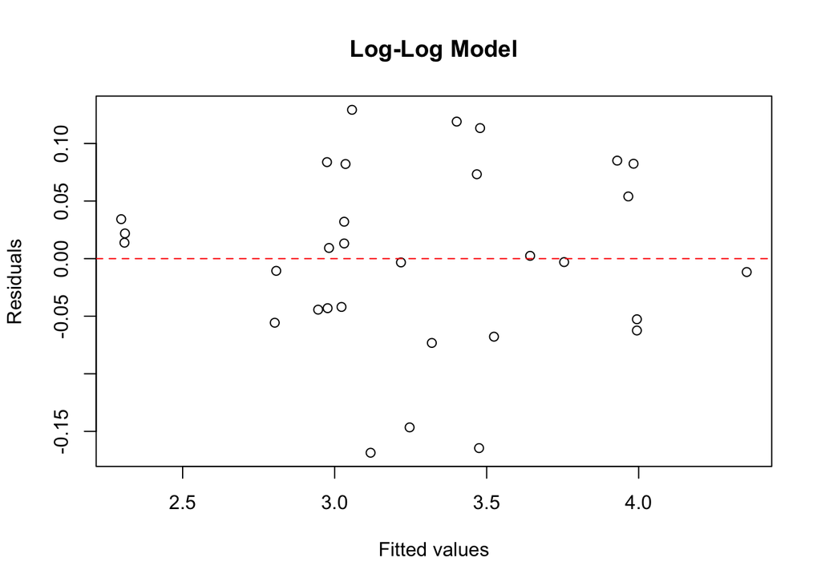

      ```r
      # Computing residuals and fitted values explicitly
      fitted_vals_creative <- fitted(model_creative)
      resids_creative <- resid(model_creative)

      plot(fitted_vals_creative, resids_creative,
           xlab = "Fitted values",
           ylab = "Residuals",
           main = "Log-Log Model")
      abline(h = 0, lty = 2, col = "red")
      ```

      The coefficients of `log(Girth)` is close to 2 and the coefficient of `log(Height)` is close to 1, which makes physical sense. The residual plot does not indicate deviation from linearity or heteroscedasticity.
2. Under model
   $$\mathbf{Y} = \mathbf{X} \boldsymbol{\beta} + \boldsymbol{\varepsilon}, \quad \boldsymbol{\varepsilon} \sim N(\mathbf{0}, \sigma^2 \mathbf{V}),$$
   we have the generalized linear square estimator $\hat{\boldsymbol{\beta}} = (\mathbf{X}' \mathbf{V}^{-1} \mathbf{X})^{-1} \mathbf{X}' \mathbf{V}^{-1} \mathbf{Y}$ and the fitted values $\hat{\mathbf{Y}} = \mathbf{X} \hat{\boldsymbol{\beta}}$. Prove the following:
   1. $\hat{\mathbf{Y}}$ is unbiased: $E(\hat{\mathbf{Y}})=\mathbf{X} \boldsymbol{\beta}$
   2. $Var(\hat{\boldsymbol{\beta}}) = \sigma^2 (\mathbf{X}' \mathbf{V}^{-1} \mathbf{X})^{-1}$
   3. $Var(\hat{\mathbf{Y}}) = \sigma^2 \mathbf{X} (\mathbf{X}' \mathbf{V}^{-1} \mathbf{X})^{-1} \mathbf{X}'$

   **Answer:**
   1. **Unbiasedness of $\hat{\mathbf{Y}}$:**
      $$\begin{align*}
      E(\hat{\mathbf{Y}}) &= E(\mathbf{X} \hat{\boldsymbol{\beta}}) = \mathbf{X} E(\hat{\boldsymbol{\beta}})
      \end{align*}$$
      First, find $E(\hat{\boldsymbol{\beta}})$:
      $$\begin{align*}
      E(\hat{\boldsymbol{\beta}}) &= E\left((\mathbf{X}' \mathbf{V}^{-1} \mathbf{X})^{-1} \mathbf{X}' \mathbf{V}^{-1} \mathbf{Y}\right) \\
      &= (\mathbf{X}' \mathbf{V}^{-1} \mathbf{X})^{-1} \mathbf{X}' \mathbf{V}^{-1} E(\mathbf{Y})
      \end{align*}$$
      Since $E(\mathbf{Y}) = \mathbf{X} \boldsymbol{\beta}$:
      $$\begin{align*}
      E(\hat{\boldsymbol{\beta}}) &= (\mathbf{X}' \mathbf{V}^{-1} \mathbf{X})^{-1} \mathbf{X}' \mathbf{V}^{-1} (\mathbf{X} \boldsymbol{\beta}) \\
      &= \left((\mathbf{X}' \mathbf{V}^{-1} \mathbf{X})^{-1} (\mathbf{X}' \mathbf{V}^{-1} \mathbf{X})\right) \boldsymbol{\beta} \\
      &= \mathbf{I} \boldsymbol{\beta} = \boldsymbol{\beta}
      \end{align*}$$
      Therefore:
      $$\begin{align*}
      E(\hat{\mathbf{Y}}) &= \mathbf{X} \boldsymbol{\beta}
      \end{align*}$$
   2. **Variance of $\hat{\boldsymbol{\beta}}$:** Using the property $Var(\mathbf{A}\mathbf{Y}) = \mathbf{A} Var(\mathbf{Y}) \mathbf{A}'$, where $\mathbf{A} = (\mathbf{X}' \mathbf{V}^{-1} \mathbf{X})^{-1} \mathbf{X}' \mathbf{V}^{-1}$:
      $$\begin{align*}
      Var(\hat{\boldsymbol{\beta}}) &= (\mathbf{X}' \mathbf{V}^{-1} \mathbf{X})^{-1} \mathbf{X}' \mathbf{V}^{-1} Var(\mathbf{Y}) \left((\mathbf{X}' \mathbf{V}^{-1} \mathbf{X})^{-1} \mathbf{X}' \mathbf{V}^{-1}\right)'
      \end{align*}$$
      Since $Var(\mathbf{Y}) = \sigma^2 \mathbf{V}$ and $\mathbf{V}$ is symmetric (so $\mathbf{V}^{-1}$ is symmetric):
      $$\begin{align*}
      Var(\hat{\boldsymbol{\beta}}) &= (\mathbf{X}' \mathbf{V}^{-1} \mathbf{X})^{-1} \mathbf{X}' \mathbf{V}^{-1} (\sigma^2 \mathbf{V}) \mathbf{V}^{-1} \mathbf{X} (\mathbf{X}' \mathbf{V}^{-1} \mathbf{X})^{-1} \\
      &= \sigma^2 (\mathbf{X}' \mathbf{V}^{-1} \mathbf{X})^{-1} \mathbf{X}' (\mathbf{V}^{-1} \mathbf{V}) \mathbf{V}^{-1} \mathbf{X} (\mathbf{X}' \mathbf{V}^{-1} \mathbf{X})^{-1} \\
      &= \sigma^2 (\mathbf{X}' \mathbf{V}^{-1} \mathbf{X})^{-1} (\mathbf{X}' \mathbf{V}^{-1} \mathbf{X}) (\mathbf{X}' \mathbf{V}^{-1} \mathbf{X})^{-1} \\
      &= \sigma^2 (\mathbf{X}' \mathbf{V}^{-1} \mathbf{X})^{-1} \mathbf{I} \\
      &= \sigma^2 (\mathbf{X}' \mathbf{V}^{-1} \mathbf{X})^{-1}
      \end{align*}$$
   3. **Variance of $\hat{\mathbf{Y}}$:** Using the property $Var(\mathbf{A}\mathbf{Y}) = \mathbf{A} Var(\mathbf{Y}) \mathbf{A}'$:
      $$\begin{align*}
      Var(\hat{\mathbf{Y}}) &= Var(\mathbf{X} \hat{\boldsymbol{\beta}}) = \mathbf{X} Var(\hat{\boldsymbol{\beta}}) \mathbf{X}'
      \end{align*}$$
      Substituting the result from part (b):
      $$\begin{align*}
      Var(\hat{\mathbf{Y}}) &= \mathbf{X} \left(\sigma^2 (\mathbf{X}' \mathbf{V}^{-1} \mathbf{X})^{-1}\right) \mathbf{X}' \\
      &= \sigma^2 \mathbf{X} (\mathbf{X}' \mathbf{V}^{-1} \mathbf{X})^{-1} \mathbf{X}'
      \end{align*}$$
3. **Weighted Least Squares (WLS) and Iteratively Reweighted Least Squares (IRLS).** Load the `Boston` dataset available in the `MASS` package using `library(MASS)` and `data(Boston)`. This dataset contains housing values in suburbs of Boston. We want to predict the median value of owner-occupied homes (`medv`) using the percentage of lower status of the population (`lstat`).
   1. **OLS Fit and Diagnostics:** Fit an Ordinary Least Squares (OLS) model `medv ~ lstat`. Plot the “Residuals vs Fitted” plot. Do you observe any evidence of non-constant variance (heteroscedasticity)? Do you observe any evidence of non-linearity?
   2. **Quadratic Model:** Based on the residual plot from part (a), fit a new OLS model that includes a quadratic term for `lstat` (i.e., `medv ~ lstat + I(lstat^2)`). Plot the “Residuals vs Fitted” plot for this new model. Did the quadratic term help with the non-linearity? Did it resolve the heteroscedasticity?
   3. **IRLS Implementation:** Suppose we believe the standard deviation of the errors is proportional to the mean home value, i.e., $\text{std}(y_i) \propto \mu_i$, which implies $Var(y_i) \propto \mu_i^2$. Since we don’t know the true mean $\mu_i$, we can estimate it using the fitted values $\hat{y}_i$ and use Iteratively Reweighted Least Squares (IRLS). Implement a simple IRLS algorithm in R with the following steps:
      1. Fit the initial OLS model: `medv ~ lstat + I(lstat^2)`.
      2. Extract the fitted values $\hat{y}_i$ from the current model.
      3. Define new weights as $w_i = 1 / (\hat{y}_i)^2$.
      4. Fit a new WLS model `medv ~ lstat + I(lstat^2)` using these new weights $w_i$.
      5. Repeat steps 2-4 for a total of 20 iterations.
   4. **Comparison:** Print the summary of the initial quadratic OLS model and the final quadratic IRLS model. Compare the estimated coefficients, their standard errors, and the $R^2$ values between the two models. How did taking heteroscedasticity into account affect the results?
   5. **Bonus point:** Implement a convergence criterion based on the change in coefficients or fitted values, and stop the iterations when the change is below a certain threshold (e.g., $10^{-6}$).

   **Answer:**
   1. **OLS Fit and Diagnostics:**

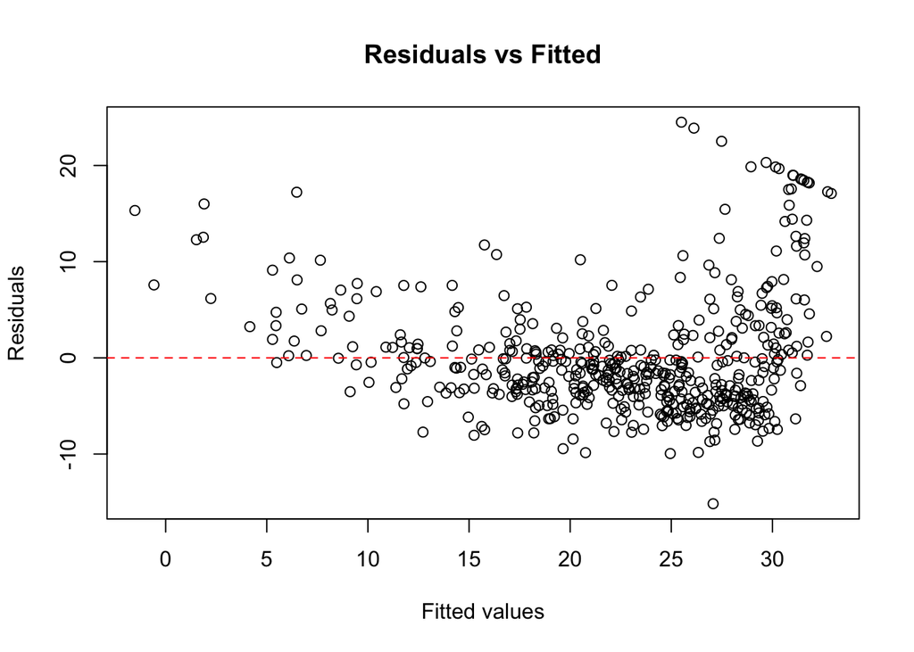

      ```r
      library(MASS)
      data(Boston)
      model_ols <- lm(medv ~ lstat, data = Boston)

      fitted_vals_ols <- fitted(model_ols)
      resids_ols <- resid(model_ols)

      plot(fitted_vals_ols, resids_ols,
           xlab = "Fitted values",
           ylab = "Residuals",
           main = "Residuals vs Fitted")
      abline(h = 0, lty = 2, col = "red")
      ```

      *Observation:* The “Residuals vs Fitted” plot shows that the residuals increases as the fitted values increase. This is strong evidence of non-constant variance (heteroscedasticity). There is also a noticeable U-shape curve, suggesting non-linearity.
   2. **Quadratic Model:**

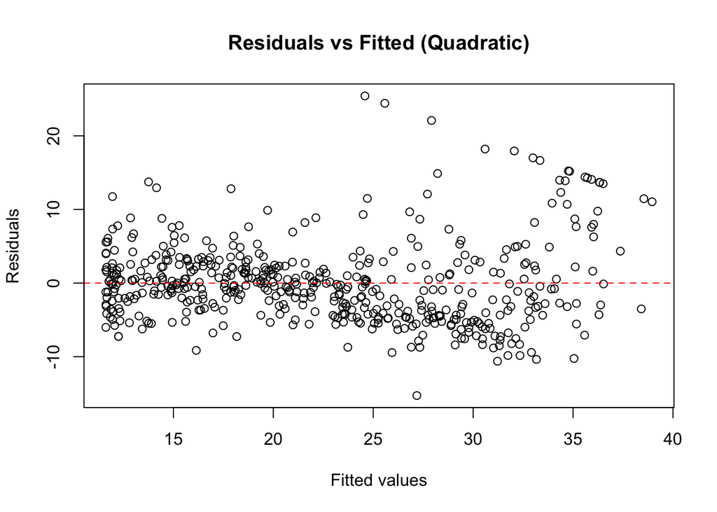

      ```r
      model_quad <- lm(medv ~ lstat + I(lstat^2), data = Boston)

      fitted_vals_quad <- fitted(model_quad)
      resids_quad <- resid(model_quad)

      plot(fitted_vals_quad, resids_quad,
           xlab = "Fitted values",
           ylab = "Residuals",
           main = "Residuals vs Fitted (Quadratic)")
      abline(h = 0, lty = 2, col = "red")
      ```

      *Observation:* The quadratic term successfully removed the U-shape curve, indicating that the non-linearity issue has been largely resolved. However, the issue of non-constant variance (heteroscedasticity) is not very obvious.
   3. **IRLS Implementation:**

      ```r
      # Step 1: Initial OLS model
      fit_w <- lm(medv ~ lstat + I(lstat^2), data = Boston)

      # Steps 2-5: Iterate 20 times
      for (i in 1:20) {
        # Step 2 & 3: Extract fitted values and define weights
        w <- 1 / (fit_w$fitted.values)^2

        # Step 4: Fit new WLS model
        fit_w <- lm(medv ~ lstat + I(lstat^2), data = Boston, weights = w)
      }

      model_irls <- fit_w
      ```

   4. **Comparison:**

      ```r
      summary(model_quad)
      ```

      ```
      Call:
      lm(formula = medv ~ lstat + I(lstat^2), data = Boston)

      Residuals:
           Min       1Q   Median       3Q      Max
      -15.2834  -3.8313  -0.5295   2.3095  25.4148

      Coefficients:
                   Estimate Std. Error t value Pr(>|t|)
      (Intercept) 42.862007   0.872084   49.15   <2e-16 ***
      lstat       -2.332821   0.123803  -18.84   <2e-16 ***
      I(lstat^2)   0.043547   0.003745   11.63   <2e-16 ***
      ---
      Signif. codes:  0 '***' 0.001 '**' 0.01 '*' 0.05 '.' 0.1 ' ' 1

      Residual standard error: 5.524 on 503 degrees of freedom
      Multiple R-squared:  0.6407,    Adjusted R-squared:  0.6393
      F-statistic: 448.5 on 2 and 503 DF,  p-value: < 2.2e-16
      ```

      ```r
      summary(model_irls)
      ```

      ```
      Call:
      lm(formula = medv ~ lstat + I(lstat^2), data = Boston, weights = w)

      Weighted Residuals:
           Min       1Q   Median       3Q      Max
      -0.60677 -0.16039 -0.03442  0.10901  1.07131

      Coefficients:
                   Estimate Std. Error t value Pr(>|t|)
      (Intercept) 40.534642   0.971279   41.73   <2e-16 ***
      lstat       -2.001305   0.112645  -17.77   <2e-16 ***
      I(lstat^2)   0.034409   0.002968   11.59   <2e-16 ***
      ---
      Signif. codes:  0 '***' 0.001 '**' 0.01 '*' 0.05 '.' 0.1 ' ' 1

      Residual standard error: 0.2418 on 503 degrees of freedom
      Multiple R-squared:  0.6394,    Adjusted R-squared:  0.638
      F-statistic:   446 on 2 and 503 DF,  p-value: < 2.2e-16
      ```

      *Comparison:*
      - The regression coefficients shifted slightly. The Multiple R-squared values are very similar (0.6407 for OLS vs 0.6394 for IRLS). From the residual plot we didn’t see much evidence of heteroscedasticity in the quadratic OLS model, so the IRLS model (weighted least squares) did not show a significant improvement in terms of $R^2$.
   5. **Bonus point:**

      ```r
      fit_converge <- lm(medv ~ lstat + I(lstat^2), data = Boston)
      coef_old <- coef(fit_converge)
      converged <- FALSE
      i <- 0
      max_iters <- 100

      while(!converged && i < max_iters) {
        i <- i + 1
        w <- 1 / (fit_converge$fitted.values)^2
        fit_converge <- lm(medv ~ lstat + I(lstat^2), data = Boston, weights = w)

        coef_new <- coef(fit_converge)
        # check convergence
        if (max(abs(coef_new - coef_old)) < 1e-6) {
          converged <- TRUE
          cat("Converged at iteration:", i, "\n")
        }
        coef_old <- coef_new
      }
      ```

      ```
      Converged at iteration: 6
      ```

      ```r
      summary(fit_converge)
      ```

      ```
      Call:
      lm(formula = medv ~ lstat + I(lstat^2), data = Boston, weights = w)

      Weighted Residuals:
           Min       1Q   Median       3Q      Max
      -0.60677 -0.16039 -0.03442  0.10901  1.07131

      Coefficients:
                   Estimate Std. Error t value Pr(>|t|)
      (Intercept) 40.534642   0.971279   41.73   <2e-16 ***
      lstat       -2.001305   0.112645  -17.77   <2e-16 ***
      I(lstat^2)   0.034409   0.002968   11.59   <2e-16 ***
      ---
      Signif. codes:  0 '***' 0.001 '**' 0.01 '*' 0.05 '.' 0.1 ' ' 1

      Residual standard error: 0.2418 on 503 degrees of freedom
      Multiple R-squared:  0.6394,    Adjusted R-squared:  0.638
      F-statistic:   446 on 2 and 503 DF,  p-value: < 2.2e-16
      ```